# Risk Factor Analysis

## Outcome Variable

**Outcome Variable:** sstunted

## Predictor Variables

**Intervention Variable:** enwast

**Adjustment Set:**

unadjusted

## Stratifying Variables

The analysis was stratified on these variable(s):

- agecat
- studyid
- country

## Data Summary

| agecat | studyid | country | enwast | sstunted | n_cell | n |
| --- | --- | --- | --- | --- | --- | --- |
| Birth | ki0047075b-MAL-ED | BANGLADESH | 0 | 0 | 200 | 241 |
| Birth | ki0047075b-MAL-ED | BANGLADESH | 0 | 1 | 1 | 241 |
| Birth | ki0047075b-MAL-ED | BANGLADESH | 1 | 0 | 40 | 241 |
| Birth | ki0047075b-MAL-ED | BANGLADESH | 1 | 1 | 0 | 241 |
| Birth | ki0047075b-MAL-ED | BRAZIL | 0 | 0 | 175 | 183 |
| Birth | ki0047075b-MAL-ED | BRAZIL | 0 | 1 | 2 | 183 |
| Birth | ki0047075b-MAL-ED | BRAZIL | 1 | 0 | 6 | 183 |
| Birth | ki0047075b-MAL-ED | BRAZIL | 1 | 1 | 0 | 183 |
| Birth | ki0047075b-MAL-ED | INDIA | 0 | 0 | 167 | 203 |
| Birth | ki0047075b-MAL-ED | INDIA | 0 | 1 | 3 | 203 |
| Birth | ki0047075b-MAL-ED | INDIA | 1 | 0 | 32 | 203 |
| Birth | ki0047075b-MAL-ED | INDIA | 1 | 1 | 1 | 203 |
| Birth | ki0047075b-MAL-ED | NEPAL | 0 | 0 | 146 | 169 |
| Birth | ki0047075b-MAL-ED | NEPAL | 0 | 1 | 2 | 169 |
| Birth | ki0047075b-MAL-ED | NEPAL | 1 | 0 | 21 | 169 |
| Birth | ki0047075b-MAL-ED | NEPAL | 1 | 1 | 0 | 169 |
| Birth | ki0047075b-MAL-ED | PERU | 0 | 0 | 271 | 279 |
| Birth | ki0047075b-MAL-ED | PERU | 0 | 1 | 2 | 279 |
| Birth | ki0047075b-MAL-ED | PERU | 1 | 0 | 6 | 279 |
| Birth | ki0047075b-MAL-ED | PERU | 1 | 1 | 0 | 279 |
| Birth | ki0047075b-MAL-ED | SOUTH AFRICA | 0 | 0 | 240 | 260 |
| Birth | ki0047075b-MAL-ED | SOUTH AFRICA | 0 | 1 | 0 | 260 |
| Birth | ki0047075b-MAL-ED | SOUTH AFRICA | 1 | 0 | 20 | 260 |
| Birth | ki0047075b-MAL-ED | SOUTH AFRICA | 1 | 1 | 0 | 260 |
| Birth | ki0047075b-MAL-ED | TANZANIA, UNITED REPUBLIC OF | 0 | 0 | 115 | 118 |
| Birth | ki0047075b-MAL-ED | TANZANIA, UNITED REPUBLIC OF | 0 | 1 | 1 | 118 |
| Birth | ki0047075b-MAL-ED | TANZANIA, UNITED REPUBLIC OF | 1 | 0 | 2 | 118 |
| Birth | ki0047075b-MAL-ED | TANZANIA, UNITED REPUBLIC OF | 1 | 1 | 0 | 118 |
| Birth | ki1000108-CMC-V-BCS-2002 | INDIA | 0 | 0 | 74 | 85 |
| Birth | ki1000108-CMC-V-BCS-2002 | INDIA | 0 | 1 | 0 | 85 |

[output cut: 314 more lines]

The following strata were considered:

- agecat: 24 months, studyid: ki0047075b-MAL-ED, country: BANGLADESH
- agecat: 24 months, studyid: ki0047075b-MAL-ED, country: BRAZIL
- agecat: 24 months, studyid: ki0047075b-MAL-ED, country: INDIA
- agecat: 24 months, studyid: ki0047075b-MAL-ED, country: NEPAL
- agecat: 24 months, studyid: ki0047075b-MAL-ED, country: PERU
- agecat: 24 months, studyid: ki0047075b-MAL-ED, country: SOUTH AFRICA
- agecat: 24 months, studyid: ki0047075b-MAL-ED, country: TANZANIA, UNITED REPUBLIC OF
- agecat: 24 months, studyid: ki1000108-CMC-V-BCS-2002, country: INDIA
- agecat: 24 months, studyid: ki1000108-IRC, country: INDIA
- agecat: 24 months, studyid: ki1017093-NIH-Birth, country: BANGLADESH
- agecat: 24 months, studyid: ki1017093b-PROVIDE, country: BANGLADESH
- agecat: 24 months, studyid: ki1017093c-NIH-Crypto, country: BANGLADESH
- agecat: 24 months, studyid: ki1066203-TanzaniaChild2, country: TANZANIA, UNITED REPUBLIC OF
- agecat: 24 months, studyid: ki1101329-Keneba, country: GAMBIA
- agecat: 24 months, studyid: ki1113344-GMS-Nepal, country: NEPAL
- agecat: 24 months, studyid: ki1114097-CMIN, country: BANGLADESH
- agecat: 24 months, studyid: ki1114097-CMIN, country: GUINEA-BISSAU
- agecat: 24 months, studyid: ki1114097-CMIN, country: PERU
- agecat: 24 months, studyid: ki1114097-CONTENT, country: PERU
- agecat: 24 months, studyid: ki1119695-PROBIT, country: BELARUS
- agecat: 24 months, studyid: ki1126311-ZVITAMBO, country: ZIMBABWE
- agecat: 24 months, studyid: ki1135781-COHORTS, country: GUATEMALA
- agecat: 24 months, studyid: ki1135781-COHORTS, country: INDIA
- agecat: 24 months, studyid: ki1135781-COHORTS, country: PHILIPPINES
- agecat: 24 months, studyid: ki1148112-LCNI-5, country: MALAWI
- agecat: 24 months, studyid: kiGH5241-JiVitA-3, country: BANGLADESH
- agecat: 24 months, studyid: kiGH5241-JiVitA-4, country: BANGLADESH
- agecat: 6 months, studyid: ki0047075b-MAL-ED, country: BANGLADESH
- agecat: 6 months, studyid: ki0047075b-MAL-ED, country: BRAZIL
- agecat: 6 months, studyid: ki0047075b-MAL-ED, country: INDIA
- agecat: 6 months, studyid: ki0047075b-MAL-ED, country: NEPAL
- agecat: 6 months, studyid: ki0047075b-MAL-ED, country: PERU
- agecat: 6 months, studyid: ki0047075b-MAL-ED, country: SOUTH AFRICA
- agecat: 6 months, studyid: ki0047075b-MAL-ED, country: TANZANIA, UNITED REPUBLIC OF
- agecat: 6 months, studyid: ki1000108-CMC-V-BCS-2002, country: INDIA
- agecat: 6 months, studyid: ki1000108-IRC, country: INDIA
- agecat: 6 months, studyid: ki1000109-EE, country: PAKISTAN
- agecat: 6 months, studyid: ki1000109-ResPak, country: PAKISTAN
- agecat: 6 months, studyid: ki1000304b-SAS-CompFeed, country: INDIA
- agecat: 6 months, studyid: ki1000304b-SAS-FoodSuppl, country: INDIA
- agecat: 6 months, studyid: ki1017093-NIH-Birth, country: BANGLADESH
- agecat: 6 months, studyid: ki1017093b-PROVIDE, country: BANGLADESH
- agecat: 6 months, studyid: ki1017093c-NIH-Crypto, country: BANGLADESH
- agecat: 6 months, studyid: ki1066203-TanzaniaChild2, country: TANZANIA, UNITED REPUBLIC OF
- agecat: 6 months, studyid: ki1101329-Keneba, country: GAMBIA
- agecat: 6 months, studyid: ki1112895-Guatemala BSC, country: GUATEMALA
- agecat: 6 months, studyid: ki1113344-GMS-Nepal, country: NEPAL
- agecat: 6 months, studyid: ki1114097-CMIN, country: BANGLADESH
- agecat: 6 months, studyid: ki1114097-CMIN, country: BRAZIL
- agecat: 6 months, studyid: ki1114097-CMIN, country: GUINEA-BISSAU
- agecat: 6 months, studyid: ki1114097-CMIN, country: PERU
- agecat: 6 months, studyid: ki1114097-CONTENT, country: PERU
- agecat: 6 months, studyid: ki1119695-PROBIT, country: BELARUS
- agecat: 6 months, studyid: ki1126311-ZVITAMBO, country: ZIMBABWE
- agecat: 6 months, studyid: ki1135781-COHORTS, country: GUATEMALA
- agecat: 6 months, studyid: ki1135781-COHORTS, country: INDIA
- agecat: 6 months, studyid: ki1135781-COHORTS, country: PHILIPPINES
- agecat: 6 months, studyid: ki1148112-LCNI-5, country: MALAWI
- agecat: 6 months, studyid: kiGH5241-JiVitA-3, country: BANGLADESH
- agecat: 6 months, studyid: kiGH5241-JiVitA-4, country: BANGLADESH
- agecat: Birth, studyid: ki0047075b-MAL-ED, country: BANGLADESH
- agecat: Birth, studyid: ki0047075b-MAL-ED, country: BRAZIL
- agecat: Birth, studyid: ki0047075b-MAL-ED, country: INDIA
- agecat: Birth, studyid: ki0047075b-MAL-ED, country: NEPAL
- agecat: Birth, studyid: ki0047075b-MAL-ED, country: PERU
- agecat: Birth, studyid: ki0047075b-MAL-ED, country: SOUTH AFRICA
- agecat: Birth, studyid: ki0047075b-MAL-ED, country: TANZANIA, UNITED REPUBLIC OF
- agecat: Birth, studyid: ki1000108-CMC-V-BCS-2002, country: INDIA
- agecat: Birth, studyid: ki1000108-IRC, country: INDIA
- agecat: Birth, studyid: ki1000109-EE, country: PAKISTAN
- agecat: Birth, studyid: ki1000109-ResPak, country: PAKISTAN
- agecat: Birth, studyid: ki1000304b-SAS-CompFeed, country: INDIA
- agecat: Birth, studyid: ki1017093-NIH-Birth, country: BANGLADESH
- agecat: Birth, studyid: ki1017093c-NIH-Crypto, country: BANGLADESH
- agecat: Birth, studyid: ki1101329-Keneba, country: GAMBIA
- agecat: Birth, studyid: ki1114097-CMIN, country: BANGLADESH
- agecat: Birth, studyid: ki1114097-CMIN, country: BRAZIL
- agecat: Birth, studyid: ki1114097-CMIN, country: PERU
- agecat: Birth, studyid: ki1114097-CONTENT, country: PERU
- agecat: Birth, studyid: ki1119695-PROBIT, country: BELARUS
- agecat: Birth, studyid: ki1126311-ZVITAMBO, country: ZIMBABWE
- agecat: Birth, studyid: ki1135781-COHORTS, country: GUATEMALA
- agecat: Birth, studyid: ki1135781-COHORTS, country: INDIA
- agecat: Birth, studyid: ki1135781-COHORTS, country: PHILIPPINES
- agecat: Birth, studyid: kiGH5241-JiVitA-3, country: BANGLADESH
- agecat: Birth, studyid: kiGH5241-JiVitA-4, country: BANGLADESH

### Dropped Strata

Some strata were dropped due to rare outcomes:

- agecat: Birth, studyid: ki0047075b-MAL-ED, country: BANGLADESH
- agecat: Birth, studyid: ki0047075b-MAL-ED, country: BRAZIL
- agecat: Birth, studyid: ki0047075b-MAL-ED, country: INDIA
- agecat: Birth, studyid: ki0047075b-MAL-ED, country: NEPAL
- agecat: Birth, studyid: ki0047075b-MAL-ED, country: PERU
- agecat: Birth, studyid: ki0047075b-MAL-ED, country: SOUTH AFRICA
- agecat: Birth, studyid: ki0047075b-MAL-ED, country: TANZANIA, UNITED REPUBLIC OF
- agecat: Birth, studyid: ki1000108-CMC-V-BCS-2002, country: INDIA
- agecat: Birth, studyid: ki1000108-IRC, country: INDIA
- agecat: Birth, studyid: ki1000109-EE, country: PAKISTAN
- agecat: Birth, studyid: ki1000109-ResPak, country: PAKISTAN
- agecat: Birth, studyid: ki1000304b-SAS-CompFeed, country: INDIA
- agecat: Birth, studyid: ki1017093-NIH-Birth, country: BANGLADESH
- agecat: Birth, studyid: ki1017093c-NIH-Crypto, country: BANGLADESH
- agecat: Birth, studyid: ki1101329-Keneba, country: GAMBIA
- agecat: Birth, studyid: ki1114097-CMIN, country: BANGLADESH
- agecat: Birth, studyid: ki1114097-CMIN, country: BRAZIL
- agecat: Birth, studyid: ki1114097-CMIN, country: PERU
- agecat: Birth, studyid: ki1114097-CONTENT, country: PERU
- agecat: Birth, studyid: ki1119695-PROBIT, country: BELARUS
- agecat: Birth, studyid: ki1126311-ZVITAMBO, country: ZIMBABWE
- agecat: Birth, studyid: ki1135781-COHORTS, country: GUATEMALA
- agecat: Birth, studyid: ki1135781-COHORTS, country: INDIA
- agecat: Birth, studyid: ki1135781-COHORTS, country: PHILIPPINES
- agecat: Birth, studyid: kiGH5241-JiVitA-3, country: BANGLADESH
- agecat: Birth, studyid: kiGH5241-JiVitA-4, country: BANGLADESH
- agecat: 6 months, studyid: ki0047075b-MAL-ED, country: BANGLADESH
- agecat: 6 months, studyid: ki0047075b-MAL-ED, country: BRAZIL
- agecat: 6 months, studyid: ki0047075b-MAL-ED, country: INDIA
- agecat: 6 months, studyid: ki0047075b-MAL-ED, country: NEPAL
- agecat: 6 months, studyid: ki0047075b-MAL-ED, country: PERU
- agecat: 6 months, studyid: ki0047075b-MAL-ED, country: SOUTH AFRICA
- agecat: 6 months, studyid: ki0047075b-MAL-ED, country: TANZANIA, UNITED REPUBLIC OF
- agecat: 6 months, studyid: ki1066203-TanzaniaChild2, country: TANZANIA, UNITED REPUBLIC OF
- agecat: 6 months, studyid: ki1112895-Guatemala BSC, country: GUATEMALA
- agecat: 6 months, studyid: ki1114097-CMIN, country: BANGLADESH
- agecat: 6 months, studyid: ki1114097-CMIN, country: BRAZIL
- agecat: 6 months, studyid: ki1114097-CMIN, country: GUINEA-BISSAU
- agecat: 6 months, studyid: ki1114097-CMIN, country: PERU
- agecat: 6 months, studyid: ki1114097-CONTENT, country: PERU
- agecat: 24 months, studyid: ki0047075b-MAL-ED, country: BRAZIL
- agecat: 24 months, studyid: ki0047075b-MAL-ED, country: NEPAL
- agecat: 24 months, studyid: ki0047075b-MAL-ED, country: PERU
- agecat: 24 months, studyid: ki0047075b-MAL-ED, country: SOUTH AFRICA
- agecat: 24 months, studyid: ki0047075b-MAL-ED, country: TANZANIA, UNITED REPUBLIC OF
- agecat: 24 months, studyid: ki1066203-TanzaniaChild2, country: TANZANIA, UNITED REPUBLIC OF
- agecat: 24 months, studyid: ki1114097-CMIN, country: PERU
- agecat: 24 months, studyid: ki1114097-CONTENT, country: PERU
- agecat: 24 months, studyid: ki1148112-LCNI-5, country: MALAWI

## Methods Detail

We’re interested in the causal parameters $E[Y_a]$ for all values of $a \in \mathcal{A}$. These parameters represent the mean outcome if, possibly contrary to fact, we intervened to set all units to have $A=a$. Under the randomization and positivity assumptions, these are identified by the statistical parameters $\psi_a=E_W[E_{Y|A,W}(Y|A=a,W)]$. In addition, we’re interested in the mean of $Y$, $E[Y]$ under no intervention (the observed mean). We will estimate these parameters by using SuperLearner to fit the relevant likelihood factors – $E_{Y|A,W}(Y|A=a,W)$ and $p(A=a|W)$, and then updating our likelihood fit using a joint TMLE.

For unadjusted analyses ($W=\{\}$), initial likelihoods were estimated using Lrnr_glm to estimate the simple $E(Y|A)$ and Lrnr_mean to estimate $p(A)$. For adjusted analyses, a small library containing Lrnr_glmnet, Lrnr_xgboost, and Lrnr_mean was used.

Having estimated these parameters, we will then use the delta method to estimate relative risks and attributable risks relative to a prespecified baseline level of $A$.

# Results Detail

## Results Plots

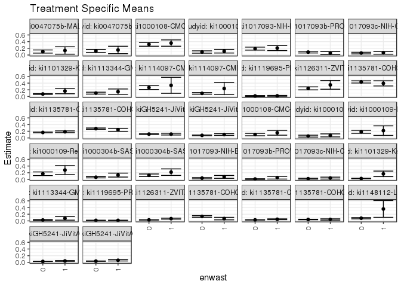

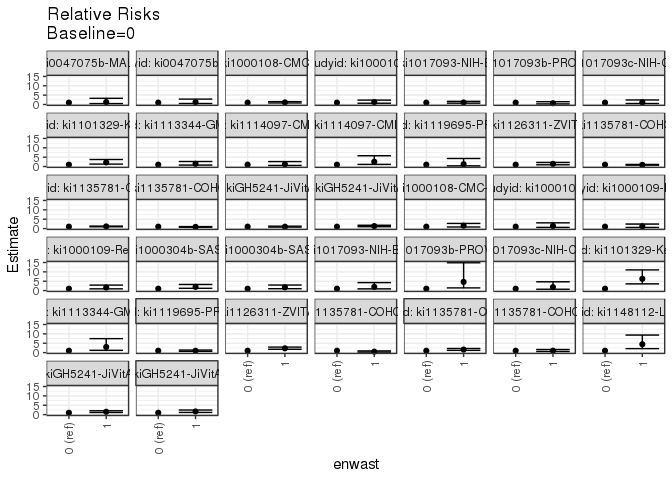

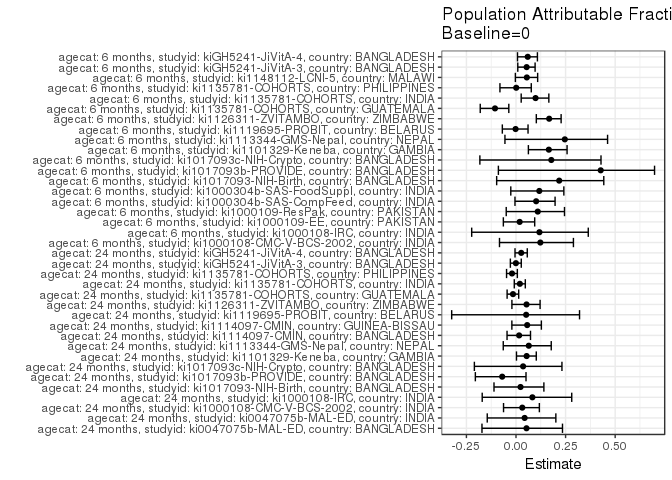

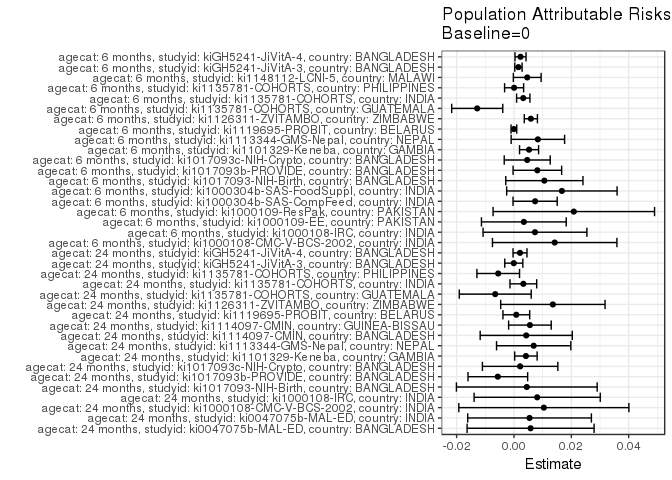

## Results Table

### Parameter: TSM

| agecat | studyid | country | intervention_level | baseline_level | estimate | ci_lower | ci_upper |
| --- | --- | --- | --- | --- | --- | --- | --- |
| 6 months | ki1000108-CMC-V-BCS-2002 | INDIA | 0 | NA | 0.1015038 | 0.0651620 | 0.1378455 |
| 6 months | ki1000108-CMC-V-BCS-2002 | INDIA | 1 | NA | 0.1546392 | 0.0825878 | 0.2266905 |
| 6 months | ki1000108-IRC | INDIA | 0 | NA | 0.0546875 | 0.0267992 | 0.0825758 |
| 6 months | ki1000108-IRC | INDIA | 1 | NA | 0.0763359 | 0.0308061 | 0.1218657 |
| 6 months | ki1000109-EE | PAKISTAN | 0 | NA | 0.1836735 | 0.1393436 | 0.2280034 |
| 6 months | ki1000109-EE | PAKISTAN | 1 | NA | 0.2187500 | 0.0752971 | 0.3622029 |
| 6 months | ki1000109-ResPak | PAKISTAN | 0 | NA | 0.1693989 | 0.1149315 | 0.2238664 |
| 6 months | ki1000109-ResPak | PAKISTAN | 1 | NA | 0.2790698 | 0.1447067 | 0.4134328 |
| 6 months | ki1000304b-SAS-CompFeed | INDIA | 0 | NA | 0.0651769 | 0.0463612 | 0.0839926 |
| 6 months | ki1000304b-SAS-CompFeed | INDIA | 1 | NA | 0.1294964 | 0.0704696 | 0.1885232 |
| 6 months | ki1000304b-SAS-FoodSuppl | INDIA | 0 | NA | 0.1254019 | 0.0885469 | 0.1622569 |
| 6 months | ki1000304b-SAS-FoodSuppl | INDIA | 1 | NA | 0.2173913 | 0.1199397 | 0.3148429 |
| 6 months | ki1017093-NIH-Birth | BANGLADESH | 0 | NA | 0.0380435 | 0.0184792 | 0.0576078 |
| 6 months | ki1017093-NIH-Birth | BANGLADESH | 1 | NA | 0.0753425 | 0.0324871 | 0.1181978 |
| 6 months | ki1017093b-PROVIDE | BANGLADESH | 0 | NA | 0.0109409 | 0.0013953 | 0.0204866 |
| 6 months | ki1017093b-PROVIDE | BANGLADESH | 1 | NA | 0.0504202 | 0.0110724 | 0.0897679 |
| 6 months | ki1017093c-NIH-Crypto | BANGLADESH | 0 | NA | 0.0213178 | 0.0088460 | 0.0337896 |
| 6 months | ki1017093c-NIH-Crypto | BANGLADESH | 1 | NA | 0.0393258 | 0.0107514 | 0.0679003 |
| 6 months | ki1101329-Keneba | GAMBIA | 0 | NA | 0.0265000 | 0.0194591 | 0.0335409 |
| 6 months | ki1101329-Keneba | GAMBIA | 1 | NA | 0.1666667 | 0.0839412 | 0.2493921 |
| 6 months | ki1113344-GMS-Nepal | NEPAL | 0 | NA | 0.0255319 | 0.0112590 | 0.0398048 |
| 6 months | ki1113344-GMS-Nepal | NEPAL | 1 | NA | 0.0769231 | 0.0221254 | 0.1317207 |
| 6 months | ki1119695-PROBIT | BELARUS | 0 | NA | 0.0153290 | 0.0096647 | 0.0209932 |
| 6 months | ki1119695-PROBIT | BELARUS | 1 | NA | 0.0151665 | 0.0095350 | 0.0207980 |
| 6 months | ki1126311-ZVITAMBO | ZIMBABWE | 0 | NA | 0.0292963 | 0.0252344 | 0.0333582 |
| 6 months | ki1126311-ZVITAMBO | ZIMBABWE | 1 | NA | 0.0670482 | 0.0530302 | 0.0810662 |
| 6 months | ki1135781-COHORTS | GUATEMALA | 0 | NA | 0.1337931 | 0.1089990 | 0.1585872 |
| 6 months | ki1135781-COHORTS | GUATEMALA | 1 | NA | 0.0681818 | 0.0309227 | 0.1054410 |
| 6 months | ki1135781-COHORTS | INDIA | 0 | NA | 0.0296421 | 0.0251031 | 0.0341810 |
| 6 months | ki1135781-COHORTS | INDIA | 1 | NA | 0.0480769 | 0.0356793 | 0.0604745 |
| 6 months | ki1135781-COHORTS | PHILIPPINES | 0 | NA | 0.0419900 | 0.0335902 | 0.0503897 |
| 6 months | ki1135781-COHORTS | PHILIPPINES | 1 | NA | 0.0422886 | 0.0226121 | 0.0619650 |
| 6 months | ki1148112-LCNI-5 | MALAWI | 0 | NA | 0.0800000 | 0.0614767 | 0.0985233 |
| 6 months | ki1148112-LCNI-5 | MALAWI | 1 | NA | 0.3571429 | 0.1059997 | 0.6082860 |
| 6 months | kiGH5241-JiVitA-3 | BANGLADESH | 0 | NA | 0.0274647 | 0.0243925 | 0.0305370 |
| 6 months | kiGH5241-JiVitA-3 | BANGLADESH | 1 | NA | 0.0419810 | 0.0306378 | 0.0533242 |
| 6 months | kiGH5241-JiVitA-4 | BANGLADESH | 0 | NA | 0.0362800 | 0.0303953 | 0.0421647 |
| 6 months | kiGH5241-JiVitA-4 | BANGLADESH | 1 | NA | 0.0613811 | 0.0406721 | 0.0820900 |
| 24 months | ki0047075b-MAL-ED | BANGLADESH | 0 | NA | 0.1036585 | 0.0568906 | 0.1504265 |
| 24 months | ki0047075b-MAL-ED | BANGLADESH | 1 | NA | 0.1351351 | 0.0247048 | 0.2455655 |
| 24 months | ki0047075b-MAL-ED | INDIA | 0 | NA | 0.1195652 | 0.0725799 | 0.1665505 |
| 24 months | ki0047075b-MAL-ED | INDIA | 1 | NA | 0.1500000 | 0.0390966 | 0.2609034 |
| 24 months | ki1000108-CMC-V-BCS-2002 | INDIA | 0 | NA | 0.3183521 | 0.2623992 | 0.3743049 |
| 24 months | ki1000108-CMC-V-BCS-2002 | INDIA | 1 | NA | 0.3571429 | 0.2621460 | 0.4521397 |
| 24 months | ki1000108-IRC | INDIA | 0 | NA | 0.0898438 | 0.0547693 | 0.1249182 |
| 24 months | ki1000108-IRC | INDIA | 1 | NA | 0.1136364 | 0.0594255 | 0.1678472 |
| 24 months | ki1017093-NIH-Birth | BANGLADESH | 0 | NA | 0.1911263 | 0.1460502 | 0.2362024 |
| 24 months | ki1017093-NIH-Birth | BANGLADESH | 1 | NA | 0.2068966 | 0.1330905 | 0.2807026 |
| 24 months | ki1017093b-PROVIDE | BANGLADESH | 0 | NA | 0.0864745 | 0.0605120 | 0.1124370 |
| 24 months | ki1017093b-PROVIDE | BANGLADESH | 1 | NA | 0.0593220 | 0.0166624 | 0.1019817 |
| 24 months | ki1017093c-NIH-Crypto | BANGLADESH | 0 | NA | 0.0578512 | 0.0338106 | 0.0818919 |
| 24 months | ki1017093c-NIH-Crypto | BANGLADESH | 1 | NA | 0.0656934 | 0.0241667 | 0.1072202 |
| 24 months | ki1101329-Keneba | GAMBIA | 0 | NA | 0.0733496 | 0.0607128 | 0.0859865 |
| 24 months | ki1101329-Keneba | GAMBIA | 1 | NA | 0.1625000 | 0.0816372 | 0.2433628 |
| 24 months | ki1113344-GMS-Nepal | NEPAL | 0 | NA | 0.0997625 | 0.0711071 | 0.1284179 |
| 24 months | ki1113344-GMS-Nepal | NEPAL | 1 | NA | 0.1447368 | 0.0655564 | 0.2239173 |
| 24 months | ki1114097-CMIN | BANGLADESH | 0 | NA | 0.2672811 | 0.2082734 | 0.3262889 |
| 24 months | ki1114097-CMIN | BANGLADESH | 1 | NA | 0.3333333 | 0.0942583 | 0.5724084 |
| 24 months | ki1114097-CMIN | GUINEA-BISSAU | 0 | NA | 0.0929791 | 0.0681626 | 0.1177956 |
| 24 months | ki1114097-CMIN | GUINEA-BISSAU | 1 | NA | 0.2380952 | 0.0557641 | 0.4204263 |
| 24 months | ki1119695-PROBIT | BELARUS | 0 | NA | 0.0150593 | 0.0004248 | 0.0296937 |
| 24 months | ki1119695-PROBIT | BELARUS | 1 | NA | 0.0186608 | 0.0057381 | 0.0315836 |
| 24 months | ki1126311-ZVITAMBO | ZIMBABWE | 0 | NA | 0.2420749 | 0.1969500 | 0.2871998 |
| 24 months | ki1126311-ZVITAMBO | ZIMBABWE | 1 | NA | 0.3461538 | 0.2166855 | 0.4756222 |
| 24 months | ki1135781-COHORTS | GUATEMALA | 0 | NA | 0.4360731 | 0.4032183 | 0.4689278 |
| 24 months | ki1135781-COHORTS | GUATEMALA | 1 | NA | 0.3921569 | 0.3147572 | 0.4695565 |
| 24 months | ki1135781-COHORTS | INDIA | 0 | NA | 0.1641580 | 0.1530231 | 0.1752930 |
| 24 months | ki1135781-COHORTS | INDIA | 1 | NA | 0.1843712 | 0.1578103 | 0.2109320 |
| 24 months | ki1135781-COHORTS | PHILIPPINES | 0 | NA | 0.2790347 | 0.2593191 | 0.2987503 |
| 24 months | ki1135781-COHORTS | PHILIPPINES | 1 | NA | 0.2430168 | 0.1985782 | 0.2874554 |
| 24 months | kiGH5241-JiVitA-3 | BANGLADESH | 0 | NA | 0.1147682 | 0.1058083 | 0.1237281 |
| 24 months | kiGH5241-JiVitA-3 | BANGLADESH | 1 | NA | 0.1142163 | 0.0880610 | 0.1403716 |
| 24 months | kiGH5241-JiVitA-4 | BANGLADESH | 0 | NA | 0.0774941 | 0.0676844 | 0.0873039 |
| 24 months | kiGH5241-JiVitA-4 | BANGLADESH | 1 | NA | 0.1017882 | 0.0747655 | 0.1288109 |

### Parameter: E(Y)

| agecat | studyid | country | intervention_level | baseline_level | estimate | ci_lower | ci_upper |
| --- | --- | --- | --- | --- | --- | --- | --- |
| 6 months | ki1000108-CMC-V-BCS-2002 | INDIA | NA | NA | 0.1157025 | 0.0827518 | 0.1486532 |
| 6 months | ki1000108-IRC | INDIA | NA | NA | 0.0620155 | 0.0379551 | 0.0860759 |
| 6 months | ki1000109-EE | PAKISTAN | NA | NA | 0.1871166 | 0.1447155 | 0.2295176 |
| 6 months | ki1000109-ResPak | PAKISTAN | NA | NA | 0.1902655 | 0.1389784 | 0.2415526 |
| 6 months | ki1000304b-SAS-CompFeed | INDIA | NA | NA | 0.0725474 | 0.0527677 | 0.0923271 |
| 6 months | ki1000304b-SAS-FoodSuppl | INDIA | NA | NA | 0.1421053 | 0.1069532 | 0.1772573 |
| 6 months | ki1017093-NIH-Birth | BANGLADESH | NA | NA | 0.0486381 | 0.0300237 | 0.0672526 |
| 6 months | ki1017093b-PROVIDE | BANGLADESH | NA | NA | 0.0190972 | 0.0079103 | 0.0302842 |
| 6 months | ki1017093c-NIH-Crypto | BANGLADESH | NA | NA | 0.0259366 | 0.0141026 | 0.0377706 |
| 6 months | ki1101329-Keneba | GAMBIA | NA | NA | 0.0317613 | 0.0242196 | 0.0393030 |
| 6 months | ki1113344-GMS-Nepal | NEPAL | NA | NA | 0.0338681 | 0.0188862 | 0.0488500 |
| 6 months | ki1119695-PROBIT | BELARUS | NA | NA | 0.0152977 | 0.0100190 | 0.0205764 |
| 6 months | ki1126311-ZVITAMBO | ZIMBABWE | NA | NA | 0.0351816 | 0.0311045 | 0.0392588 |
| 6 months | ki1135781-COHORTS | GUATEMALA | NA | NA | 0.1209767 | 0.0996719 | 0.1422815 |
| 6 months | ki1135781-COHORTS | INDIA | NA | NA | 0.0328826 | 0.0285497 | 0.0372155 |
| 6 months | ki1135781-COHORTS | PHILIPPINES | NA | NA | 0.0420363 | 0.0343109 | 0.0497616 |
| 6 months | ki1148112-LCNI-5 | MALAWI | NA | NA | 0.0846246 | 0.0657805 | 0.1034686 |
| 6 months | kiGH5241-JiVitA-3 | BANGLADESH | NA | NA | 0.0290217 | 0.0260653 | 0.0319781 |
| 6 months | kiGH5241-JiVitA-4 | BANGLADESH | NA | NA | 0.0385598 | 0.0328778 | 0.0442418 |
| 24 months | ki0047075b-MAL-ED | BANGLADESH | NA | NA | 0.1094527 | 0.0661839 | 0.1527215 |
| 24 months | ki0047075b-MAL-ED | INDIA | NA | NA | 0.1250000 | 0.0815935 | 0.1684065 |
| 24 months | ki1000108-CMC-V-BCS-2002 | INDIA | NA | NA | 0.3287671 | 0.2805081 | 0.3770261 |
| 24 months | ki1000108-IRC | INDIA | NA | NA | 0.0979381 | 0.0683249 | 0.1275514 |
| 24 months | ki1017093-NIH-Birth | BANGLADESH | NA | NA | 0.1955990 | 0.1571099 | 0.2340881 |
| 24 months | ki1017093b-PROVIDE | BANGLADESH | NA | NA | 0.0808436 | 0.0584259 | 0.1032613 |
| 24 months | ki1017093c-NIH-Crypto | BANGLADESH | NA | NA | 0.0600000 | 0.0391629 | 0.0808371 |
| 24 months | ki1101329-Keneba | GAMBIA | NA | NA | 0.0775058 | 0.0648507 | 0.0901609 |
| 24 months | ki1113344-GMS-Nepal | NEPAL | NA | NA | 0.1066398 | 0.0794767 | 0.1338030 |
| 24 months | ki1114097-CMIN | BANGLADESH | NA | NA | 0.2715517 | 0.2141972 | 0.3289063 |
| 24 months | ki1114097-CMIN | GUINEA-BISSAU | NA | NA | 0.0985401 | 0.0735635 | 0.1235168 |
| 24 months | ki1119695-PROBIT | BELARUS | NA | NA | 0.0158730 | 0.0044440 | 0.0273021 |
| 24 months | ki1126311-ZVITAMBO | ZIMBABWE | NA | NA | 0.2556391 | 0.2127831 | 0.2984951 |
| 24 months | ki1135781-COHORTS | GUATEMALA | NA | NA | 0.4295432 | 0.3992834 | 0.4598031 |
| 24 months | ki1135781-COHORTS | INDIA | NA | NA | 0.1674226 | 0.1571457 | 0.1776995 |
| 24 months | ki1135781-COHORTS | PHILIPPINES | NA | NA | 0.2735407 | 0.2555022 | 0.2915792 |
| 24 months | kiGH5241-JiVitA-3 | BANGLADESH | NA | NA | 0.1147053 | 0.1062340 | 0.1231766 |
| 24 months | kiGH5241-JiVitA-4 | BANGLADESH | NA | NA | 0.0795955 | 0.0702601 | 0.0889308 |

### Parameter: RR

| agecat | studyid | country | intervention_level | baseline_level | estimate | ci_lower | ci_upper |
| --- | --- | --- | --- | --- | --- | --- | --- |
| 6 months | ki1000108-CMC-V-BCS-2002 | INDIA | 0 | 0 | 1.0000000 | 1.0000000 | 1.0000000 |
| 6 months | ki1000108-CMC-V-BCS-2002 | INDIA | 1 | 0 | 1.5234822 | 0.8465322 | 2.7417718 |
| 6 months | ki1000108-IRC | INDIA | 0 | 0 | 1.0000000 | 1.0000000 | 1.0000000 |
| 6 months | ki1000108-IRC | INDIA | 1 | 0 | 1.3958561 | 0.6368510 | 3.0594506 |
| 6 months | ki1000109-EE | PAKISTAN | 0 | 0 | 1.0000000 | 1.0000000 | 1.0000000 |
| 6 months | ki1000109-EE | PAKISTAN | 1 | 0 | 1.1909722 | 0.5921368 | 2.3954175 |
| 6 months | ki1000109-ResPak | PAKISTAN | 0 | 0 | 1.0000000 | 1.0000000 | 1.0000000 |
| 6 months | ki1000109-ResPak | PAKISTAN | 1 | 0 | 1.6474119 | 0.9233428 | 2.9392831 |
| 6 months | ki1000304b-SAS-CompFeed | INDIA | 0 | 0 | 1.0000000 | 1.0000000 | 1.0000000 |
| 6 months | ki1000304b-SAS-CompFeed | INDIA | 1 | 0 | 1.9868448 | 1.2099150 | 3.2626692 |
| 6 months | ki1000304b-SAS-FoodSuppl | INDIA | 0 | 0 | 1.0000000 | 1.0000000 | 1.0000000 |
| 6 months | ki1000304b-SAS-FoodSuppl | INDIA | 1 | 0 | 1.7335563 | 1.0142465 | 2.9630049 |
| 6 months | ki1017093-NIH-Birth | BANGLADESH | 0 | 0 | 1.0000000 | 1.0000000 | 1.0000000 |
| 6 months | ki1017093-NIH-Birth | BANGLADESH | 1 | 0 | 1.9804305 | 0.9198892 | 4.2636714 |
| 6 months | ki1017093b-PROVIDE | BANGLADESH | 0 | 0 | 1.0000000 | 1.0000000 | 1.0000000 |
| 6 months | ki1017093b-PROVIDE | BANGLADESH | 1 | 0 | 4.6084034 | 1.4294855 | 14.8566610 |
| 6 months | ki1017093c-NIH-Crypto | BANGLADESH | 0 | 0 | 1.0000000 | 1.0000000 | 1.0000000 |
| 6 months | ki1017093c-NIH-Crypto | BANGLADESH | 1 | 0 | 1.8447395 | 0.7257688 | 4.6889094 |
| 6 months | ki1101329-Keneba | GAMBIA | 0 | 0 | 1.0000000 | 1.0000000 | 1.0000000 |
| 6 months | ki1101329-Keneba | GAMBIA | 1 | 0 | 6.2893082 | 3.5817786 | 11.0435070 |
| 6 months | ki1113344-GMS-Nepal | NEPAL | 0 | 0 | 1.0000000 | 1.0000000 | 1.0000000 |
| 6 months | ki1113344-GMS-Nepal | NEPAL | 1 | 0 | 3.0128205 | 1.2181721 | 7.4513996 |
| 6 months | ki1119695-PROBIT | BELARUS | 0 | 0 | 1.0000000 | 1.0000000 | 1.0000000 |
| 6 months | ki1119695-PROBIT | BELARUS | 1 | 0 | 0.9894004 | 0.7058306 | 1.3868953 |
| 6 months | ki1126311-ZVITAMBO | ZIMBABWE | 0 | 0 | 1.0000000 | 1.0000000 | 1.0000000 |
| 6 months | ki1126311-ZVITAMBO | ZIMBABWE | 1 | 0 | 2.2886261 | 1.7808354 | 2.9412091 |
| 6 months | ki1135781-COHORTS | GUATEMALA | 0 | 0 | 1.0000000 | 1.0000000 | 1.0000000 |
| 6 months | ki1135781-COHORTS | GUATEMALA | 1 | 0 | 0.5096064 | 0.2861752 | 0.9074814 |
| 6 months | ki1135781-COHORTS | INDIA | 0 | 0 | 1.0000000 | 1.0000000 | 1.0000000 |
| 6 months | ki1135781-COHORTS | INDIA | 1 | 0 | 1.6219158 | 1.2016558 | 2.1891551 |
| 6 months | ki1135781-COHORTS | PHILIPPINES | 0 | 0 | 1.0000000 | 1.0000000 | 1.0000000 |
| 6 months | ki1135781-COHORTS | PHILIPPINES | 1 | 0 | 1.0071112 | 0.6069038 | 1.6712253 |
| 6 months | ki1148112-LCNI-5 | MALAWI | 0 | 0 | 1.0000000 | 1.0000000 | 1.0000000 |
| 6 months | ki1148112-LCNI-5 | MALAWI | 1 | 0 | 4.4642857 | 2.1292496 | 9.3600332 |
| 6 months | kiGH5241-JiVitA-3 | BANGLADESH | 0 | 0 | 1.0000000 | 1.0000000 | 1.0000000 |
| 6 months | kiGH5241-JiVitA-3 | BANGLADESH | 1 | 0 | 1.5285412 | 1.1357450 | 2.0571857 |
| 6 months | kiGH5241-JiVitA-4 | BANGLADESH | 0 | 0 | 1.0000000 | 1.0000000 | 1.0000000 |
| 6 months | kiGH5241-JiVitA-4 | BANGLADESH | 1 | 0 | 1.6918699 | 1.1650349 | 2.4569425 |
| 24 months | ki0047075b-MAL-ED | BANGLADESH | 0 | 0 | 1.0000000 | 1.0000000 | 1.0000000 |
| 24 months | ki0047075b-MAL-ED | BANGLADESH | 1 | 0 | 1.3036566 | 0.5125857 | 3.3155829 |
| 24 months | ki0047075b-MAL-ED | INDIA | 0 | 0 | 1.0000000 | 1.0000000 | 1.0000000 |
| 24 months | ki0047075b-MAL-ED | INDIA | 1 | 0 | 1.2545455 | 0.5430650 | 2.8981511 |
| 24 months | ki1000108-CMC-V-BCS-2002 | INDIA | 0 | 0 | 1.0000000 | 1.0000000 | 1.0000000 |
| 24 months | ki1000108-CMC-V-BCS-2002 | INDIA | 1 | 0 | 1.1218487 | 0.8155965 | 1.5430970 |
| 24 months | ki1000108-IRC | INDIA | 0 | 0 | 1.0000000 | 1.0000000 | 1.0000000 |
| 24 months | ki1000108-IRC | INDIA | 1 | 0 | 1.2648221 | 0.6828358 | 2.3428401 |
| 24 months | ki1017093-NIH-Birth | BANGLADESH | 0 | 0 | 1.0000000 | 1.0000000 | 1.0000000 |
| 24 months | ki1017093-NIH-Birth | BANGLADESH | 1 | 0 | 1.0825123 | 0.7058458 | 1.6601826 |
| 24 months | ki1017093b-PROVIDE | BANGLADESH | 0 | 0 | 1.0000000 | 1.0000000 | 1.0000000 |
| 24 months | ki1017093b-PROVIDE | BANGLADESH | 1 | 0 | 0.6860061 | 0.3146966 | 1.4954226 |
| 24 months | ki1017093c-NIH-Crypto | BANGLADESH | 0 | 0 | 1.0000000 | 1.0000000 | 1.0000000 |
| 24 months | ki1017093c-NIH-Crypto | BANGLADESH | 1 | 0 | 1.1355579 | 0.5329294 | 2.4196293 |
| 24 months | ki1101329-Keneba | GAMBIA | 0 | 0 | 1.0000000 | 1.0000000 | 1.0000000 |
| 24 months | ki1101329-Keneba | GAMBIA | 1 | 0 | 2.2154167 | 1.3084505 | 3.7510559 |
| 24 months | ki1113344-GMS-Nepal | NEPAL | 0 | 0 | 1.0000000 | 1.0000000 | 1.0000000 |
| 24 months | ki1113344-GMS-Nepal | NEPAL | 1 | 0 | 1.4508145 | 0.7821081 | 2.6912683 |
| 24 months | ki1114097-CMIN | BANGLADESH | 0 | 0 | 1.0000000 | 1.0000000 | 1.0000000 |
| 24 months | ki1114097-CMIN | BANGLADESH | 1 | 0 | 1.2471264 | 0.5888451 | 2.6413131 |
| 24 months | ki1114097-CMIN | GUINEA-BISSAU | 0 | 0 | 1.0000000 | 1.0000000 | 1.0000000 |
| 24 months | ki1114097-CMIN | GUINEA-BISSAU | 1 | 0 | 2.5607386 | 1.1380602 | 5.7618938 |
| 24 months | ki1119695-PROBIT | BELARUS | 0 | 0 | 1.0000000 | 1.0000000 | 1.0000000 |
| 24 months | ki1119695-PROBIT | BELARUS | 1 | 0 | 1.2391573 | 0.3583536 | 4.2849041 |
| 24 months | ki1126311-ZVITAMBO | ZIMBABWE | 0 | 0 | 1.0000000 | 1.0000000 | 1.0000000 |
| 24 months | ki1126311-ZVITAMBO | ZIMBABWE | 1 | 0 | 1.4299451 | 0.9415175 | 2.1717523 |
| 24 months | ki1135781-COHORTS | GUATEMALA | 0 | 0 | 1.0000000 | 1.0000000 | 1.0000000 |
| 24 months | ki1135781-COHORTS | GUATEMALA | 1 | 0 | 0.8992917 | 0.7280333 | 1.1108359 |
| 24 months | ki1135781-COHORTS | INDIA | 0 | 0 | 1.0000000 | 1.0000000 | 1.0000000 |
| 24 months | ki1135781-COHORTS | INDIA | 1 | 0 | 1.1231322 | 0.9578056 | 1.3169958 |
| 24 months | ki1135781-COHORTS | PHILIPPINES | 0 | 0 | 1.0000000 | 1.0000000 | 1.0000000 |
| 24 months | ki1135781-COHORTS | PHILIPPINES | 1 | 0 | 0.8709195 | 0.7158792 | 1.0595374 |
| 24 months | kiGH5241-JiVitA-3 | BANGLADESH | 0 | 0 | 1.0000000 | 1.0000000 | 1.0000000 |
| 24 months | kiGH5241-JiVitA-3 | BANGLADESH | 1 | 0 | 0.9951911 | 0.7811480 | 1.2678843 |
| 24 months | kiGH5241-JiVitA-4 | BANGLADESH | 0 | 0 | 1.0000000 | 1.0000000 | 1.0000000 |
| 24 months | kiGH5241-JiVitA-4 | BANGLADESH | 1 | 0 | 1.3134951 | 0.9826378 | 1.7557531 |

### Parameter: PAR

| agecat | studyid | country | intervention_level | baseline_level | estimate | ci_lower | ci_upper |
| --- | --- | --- | --- | --- | --- | --- | --- |
| 6 months | ki1000108-CMC-V-BCS-2002 | INDIA | 0 | NA | 0.0141987 | -0.0075007 | 0.0358982 |
| 6 months | ki1000108-IRC | INDIA | 0 | NA | 0.0073280 | -0.0107742 | 0.0254302 |
| 6 months | ki1000109-EE | PAKISTAN | 0 | NA | 0.0034431 | -0.0113388 | 0.0182250 |
| 6 months | ki1000109-ResPak | PAKISTAN | 0 | NA | 0.0208666 | -0.0072863 | 0.0490195 |
| 6 months | ki1000304b-SAS-CompFeed | INDIA | 0 | NA | 0.0073705 | -0.0003326 | 0.0150736 |
| 6 months | ki1000304b-SAS-FoodSuppl | INDIA | 0 | NA | 0.0167033 | -0.0025489 | 0.0359556 |
| 6 months | ki1017093-NIH-Birth | BANGLADESH | 0 | NA | 0.0105947 | -0.0028657 | 0.0240550 |
| 6 months | ki1017093b-PROVIDE | BANGLADESH | 0 | NA | 0.0081563 | -0.0003100 | 0.0166226 |
| 6 months | ki1017093c-NIH-Crypto | BANGLADESH | 0 | NA | 0.0046188 | -0.0033992 | 0.0126368 |
| 6 months | ki1101329-Keneba | GAMBIA | 0 | NA | 0.0052613 | 0.0019409 | 0.0085817 |
| 6 months | ki1113344-GMS-Nepal | NEPAL | 0 | NA | 0.0083362 | -0.0009822 | 0.0176546 |
| 6 months | ki1119695-PROBIT | BELARUS | 0 | NA | -0.0000313 | -0.0010255 | 0.0009629 |
| 6 months | ki1126311-ZVITAMBO | ZIMBABWE | 0 | NA | 0.0058854 | 0.0035900 | 0.0081807 |
| 6 months | ki1135781-COHORTS | GUATEMALA | 0 | NA | -0.0128164 | -0.0217224 | -0.0039104 |
| 6 months | ki1135781-COHORTS | INDIA | 0 | NA | 0.0032405 | 0.0009135 | 0.0055676 |
| 6 months | ki1135781-COHORTS | PHILIPPINES | 0 | NA | 0.0000463 | -0.0032705 | 0.0033631 |
| 6 months | ki1148112-LCNI-5 | MALAWI | 0 | NA | 0.0046246 | -0.0002164 | 0.0094655 |
| 6 months | kiGH5241-JiVitA-3 | BANGLADESH | 0 | NA | 0.0015570 | 0.0002806 | 0.0028334 |
| 6 months | kiGH5241-JiVitA-4 | BANGLADESH | 0 | NA | 0.0022798 | 0.0003531 | 0.0042065 |
| 24 months | ki0047075b-MAL-ED | BANGLADESH | 0 | NA | 0.0057942 | -0.0163463 | 0.0279347 |
| 24 months | ki0047075b-MAL-ED | INDIA | 0 | NA | 0.0054348 | -0.0161277 | 0.0269973 |
| 24 months | ki1000108-CMC-V-BCS-2002 | INDIA | 0 | NA | 0.0104151 | -0.0192390 | 0.0400691 |
| 24 months | ki1000108-IRC | INDIA | 0 | NA | 0.0080944 | -0.0139007 | 0.0300895 |
| 24 months | ki1017093-NIH-Birth | BANGLADESH | 0 | NA | 0.0044727 | -0.0200650 | 0.0290104 |
| 24 months | ki1017093b-PROVIDE | BANGLADESH | 0 | NA | -0.0056309 | -0.0160268 | 0.0047650 |
| 24 months | ki1017093c-NIH-Crypto | BANGLADESH | 0 | NA | 0.0021488 | -0.0110023 | 0.0152998 |
| 24 months | ki1101329-Keneba | GAMBIA | 0 | NA | 0.0041562 | 0.0002383 | 0.0080741 |
| 24 months | ki1113344-GMS-Nepal | NEPAL | 0 | NA | 0.0068774 | -0.0060778 | 0.0198325 |
| 24 months | ki1114097-CMIN | BANGLADESH | 0 | NA | 0.0042706 | -0.0117879 | 0.0203291 |
| 24 months | ki1114097-CMIN | GUINEA-BISSAU | 0 | NA | 0.0055610 | -0.0018669 | 0.0129890 |
| 24 months | ki1119695-PROBIT | BELARUS | 0 | NA | 0.0008137 | -0.0038460 | 0.0054735 |
| 24 months | ki1126311-ZVITAMBO | ZIMBABWE | 0 | NA | 0.0135642 | -0.0046330 | 0.0317613 |
| 24 months | ki1135781-COHORTS | GUATEMALA | 0 | NA | -0.0065298 | -0.0190686 | 0.0060089 |
| 24 months | ki1135781-COHORTS | INDIA | 0 | NA | 0.0032646 | -0.0013914 | 0.0079205 |
| 24 months | ki1135781-COHORTS | PHILIPPINES | 0 | NA | -0.0054940 | -0.0129281 | 0.0019401 |
| 24 months | kiGH5241-JiVitA-3 | BANGLADESH | 0 | NA | -0.0000629 | -0.0032179 | 0.0030920 |
| 24 months | kiGH5241-JiVitA-4 | BANGLADESH | 0 | NA | 0.0021013 | -0.0003297 | 0.0045324 |

### Parameter: PAF

| agecat | studyid | country | intervention_level | baseline_level | estimate | ci_lower | ci_upper |
| --- | --- | --- | --- | --- | --- | --- | --- |
| 6 months | ki1000108-CMC-V-BCS-2002 | INDIA | 0 | NA | 0.1227175 | -0.0832594 | 0.2895288 |
| 6 months | ki1000108-IRC | INDIA | 0 | NA | 0.1181641 | -0.2234020 | 0.3643671 |
| 6 months | ki1000109-EE | PAKISTAN | 0 | NA | 0.0184008 | -0.0637979 | 0.0942481 |
| 6 months | ki1000109-ResPak | PAKISTAN | 0 | NA | 0.1096709 | -0.0492635 | 0.2445310 |
| 6 months | ki1000304b-SAS-CompFeed | INDIA | 0 | NA | 0.1015956 | -0.0051720 | 0.1970225 |
| 6 months | ki1000304b-SAS-FoodSuppl | INDIA | 0 | NA | 0.1175420 | -0.0262974 | 0.2412217 |
| 6 months | ki1017093-NIH-Birth | BANGLADESH | 0 | NA | 0.2178261 | -0.0975118 | 0.4425608 |
| 6 months | ki1017093b-PROVIDE | BANGLADESH | 0 | NA | 0.4270937 | -0.0888394 | 0.6985583 |
| 6 months | ki1017093c-NIH-Crypto | BANGLADESH | 0 | NA | 0.1780792 | -0.1821916 | 0.4285582 |
| 6 months | ki1101329-Keneba | GAMBIA | 0 | NA | 0.1656515 | 0.0624562 | 0.2574881 |
| 6 months | ki1113344-GMS-Nepal | NEPAL | 0 | NA | 0.2461366 | -0.0557717 | 0.4617113 |
| 6 months | ki1119695-PROBIT | BELARUS | 0 | NA | -0.0020448 | -0.0689602 | 0.0606817 |
| 6 months | ki1126311-ZVITAMBO | ZIMBABWE | 0 | NA | 0.1672849 | 0.1024030 | 0.2274770 |
| 6 months | ki1135781-COHORTS | GUATEMALA | 0 | NA | -0.1059412 | -0.1802875 | -0.0362779 |
| 6 months | ki1135781-COHORTS | INDIA | 0 | NA | 0.0985490 | 0.0261484 | 0.1655670 |
| 6 months | ki1135781-COHORTS | PHILIPPINES | 0 | NA | 0.0011013 | -0.0810028 | 0.0769693 |
| 6 months | ki1148112-LCNI-5 | MALAWI | 0 | NA | 0.0546479 | -0.0031785 | 0.1091410 |
| 6 months | kiGH5241-JiVitA-3 | BANGLADESH | 0 | NA | 0.0536485 | 0.0089805 | 0.0963032 |
| 6 months | kiGH5241-JiVitA-4 | BANGLADESH | 0 | NA | 0.0591236 | 0.0075790 | 0.1079910 |
| 24 months | ki0047075b-MAL-ED | BANGLADESH | 0 | NA | 0.0529379 | -0.1715422 | 0.2344052 |
| 24 months | ki0047075b-MAL-ED | INDIA | 0 | NA | 0.0434783 | -0.1449793 | 0.2009167 |
| 24 months | ki1000108-CMC-V-BCS-2002 | INDIA | 0 | NA | 0.0316792 | -0.0628463 | 0.1177979 |
| 24 months | ki1000108-IRC | INDIA | 0 | NA | 0.0826480 | -0.1703871 | 0.2809775 |
| 24 months | ki1017093-NIH-Birth | BANGLADESH | 0 | NA | 0.0228669 | -0.1109428 | 0.1405596 |
| 24 months | ki1017093b-PROVIDE | BANGLADESH | 0 | NA | -0.0696520 | -0.2049603 | 0.0504622 |
| 24 months | ki1017093c-NIH-Crypto | BANGLADESH | 0 | NA | 0.0358127 | -0.2098968 | 0.2316227 |
| 24 months | ki1101329-Keneba | GAMBIA | 0 | NA | 0.0536243 | 0.0023769 | 0.1022391 |
| 24 months | ki1113344-GMS-Nepal | NEPAL | 0 | NA | 0.0644915 | -0.0642492 | 0.1776587 |
| 24 months | ki1114097-CMIN | BANGLADESH | 0 | NA | 0.0157267 | -0.0451956 | 0.0730980 |
| 24 months | ki1114097-CMIN | GUINEA-BISSAU | 0 | NA | 0.0564340 | -0.0208643 | 0.1278795 |
| 24 months | ki1119695-PROBIT | BELARUS | 0 | NA | 0.0512656 | -0.3243162 | 0.3203308 |
| 24 months | ki1126311-ZVITAMBO | ZIMBABWE | 0 | NA | 0.0530598 | -0.0206572 | 0.1214527 |
| 24 months | ki1135781-COHORTS | GUATEMALA | 0 | NA | -0.0152018 | -0.0448270 | 0.0135835 |
| 24 months | ki1135781-COHORTS | INDIA | 0 | NA | 0.0194989 | -0.0086928 | 0.0469027 |
| 24 months | ki1135781-COHORTS | PHILIPPINES | 0 | NA | -0.0200848 | -0.0476197 | 0.0067264 |
| 24 months | kiGH5241-JiVitA-3 | BANGLADESH | 0 | NA | -0.0005486 | -0.0284361 | 0.0265827 |
| 24 months | kiGH5241-JiVitA-4 | BANGLADESH | 0 | NA | 0.0264002 | -0.0050099 | 0.0568287 |